# 07 Plots

Plotting is probably one of the most fun things to do in `R`, because you get a lot of “visual feedback” - if your code is correct, you are rewarded with a nice plot. While base `R` has a plotting function, the `tidyverse`’s `ggplot2` is a much more advanced package for plotting. It has helped `R` to achieve its reputation as a great tool for data visualisation. `ggplot2` is based on the [“Grammar of Graphics” by Leland Wilkinson](https://www.springer.com/de/book/9780387245447), a framework for good data visualisation in data science.

## Call other scripts

First, we need some data. If the data from previous exercises is still in your environment, use this opportunity to clear your workspace using `rm(list = ls())`. We want to start with a clean slate. However, the work we did in the previous data wrangling script should not go to waste. Luckily, we can “call” other scripts from within the script we are currently working in. That means, we could run `06_data_wrangling.Rmd` where all of the data cleaning was done, and would end up with a cleaned version of our nerd data. In fact, it’s good practice to distribute your code across several scripts so you know where to find what. The preprocessing could e.g. go into one script, the analysis into another one and then you could have a separate script for plots or tables.

However, `06_data_wrangling.Rmd` does not only contain the code to clean the nerd data, but much more other code that we don’t need right now. It is also an R Markdown file, and we don’t want to render the entire file into an html. At this point, we will use a “normal” `R` script that contains nothing but the code that cleans our nerd data. Unlike an `.Rmd` file, it will not create a nice document with descriptions and results - it will simply run the preprocessing in the background.

I put all the preprocessing we did in the previous exercise into a script called `"nerd_preprocessing.R"` that is lying in this folder. Open it and take a look at what’s happening at each step in the script.

Before we run our preprocessing script, we still need to load the libraries we want to use. We could also load our libraries in the preprocessing script, but then it’s less obvious which libraries we are using, because they are “hidden” in a different script. I like to list all of my libraries at the top of in the main document.

```r
library(tidyverse)
```

We can call other scripts using the function `source()`. It takes the path to the file you would like to run as it’s first argument.

```r
# Read in data and preprocess it
nerd <- read.csv("exercises/data_sets/nerd_data_short.csv", sep = "\t")
source("exercises/nerd_preprocessing.R")

# Should the paths above return an error for you, try going to
# Tools -> Global Options -> R Markdown
# and set "evaluate chunks in directory:" to "Project"
```

## Simple plots

One basic plot that you will frequently need is a histogram. It’s a good way to quickly inspect the distribution of your data. Below, you see how a simple histogram for the participant age works.

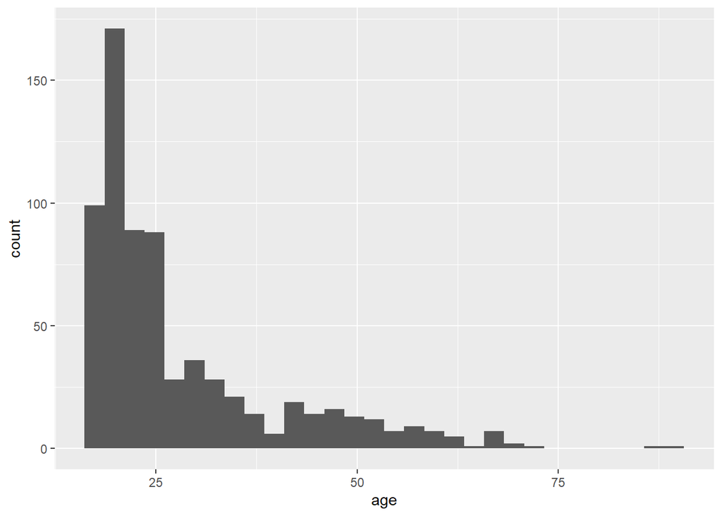

```r
nerd_red %>%
  ggplot(aes(x = age)) +
  geom_histogram()
```

The concept is pretty simple: We pipe our data, `nerd_red` into the `ggplot()` function. Within the function, we use the `aes()` function, which stands for “aesthetics”. The aesthetic function is used to tell `ggplot()` all the information that is related to the data (as opposed to things that have nothing to do with the data, e.g. overall plot colour). It will make more sense once we see which things belong into `aes()` and which things belong outside of it. Unsurprisingly, the argument `x` is what we want to put on the x-axis, which is the age of our participants in this case. Lastly, we tell `ggplot()` to make a histogram from our data. `ggplot2` uses different “geoms”, which you can imagine as different “geometric” plot shapes. Here, we use a geom called `geom_histogram`. Other geoms are for example `geom_point`, `geom_bar` or `geom_boxplot`. You can probably guess what they do. Note that we don’t use a pipe to add the histogram, but a plus sign. That is because `ggplot()` works with “layers”. It’s a bit like using PowerPoint: When you created a slide, some elements are behind/in front of each other. In `ggplot2`, it’s the same principle. Here, we already use two layers: The plot background as first layer (created by the `ggplot()` function), and then our histogram on top of that.